# Module One Discussion: Descriptive Statistics and Plots

My name is Angel Davila. I am currently working as a full stack Software Engineer for Salesloft. I primarily work in web development but also have a huge interest in data and machine learning. I have a ton of experience with Python, having built multiple web application and API's at my previous company. I decided to come back to school to finally finish out my undergrad in Computer Science with the goal to continue my studies after the undergrad.

### Step 1: Preparing the dataset

This block of Python code will generate the sample data in a Python dataframe that will be used in the calculations later. Your task is to use a website to collect the daily maximum temperature data for your city or zip code for the past fourteen days. Then, input your data in the code below by filling in the Python list. After entering your data in the Python list, click the code section below and hit the **Run** button above.

```python
import pandas as pd

# list of 14 day max temps in my area
temperatures = [39, 61, 58, 39, 39, 42, 51, 37, 32, 35, 38, 39]

# temp dataframe
temperatures_df = pd.DataFrame(temperatures, columns=['temperature'])

# print temperatures dataframe
print(temperatures_df)
```

```
    temperature
0            39
1            61
2            58
3            39
4            39
5            42
6            51
7            37
8            32
9            35
10           38
11           39
```

### Step 2: Calculating descriptive statistics

Below are the descriptive statistics from my local daily max temperature.

```python
# Pandas dataframe has several methods that calculate descriptive statistics.

# mean
mean = temperatures_df['temperature'].mean()
print("Mean=", round(mean,2))

# median
median = temperatures_df['temperature'].median()
print("Median=", round(median,2))

# variance
variance = temperatures_df['temperature'].var()
print("Variance=", round(variance,2))

# standard deviation
stdeviation = temperatures_df['temperature'].std()
print("Standard Deviation=", round(stdeviation,2))

# describe - a useful function that calculates several different descriptive statistics
statistics = temperatures_df['temperature'].describe()

print ("\nDescribe method")
print (statistics)
```

```
Mean= 42.5
Median= 39.0
Variance= 83.73
Standard Deviation= 9.15

Describe method
count    12.000000
mean     42.500000
std       9.150261
min      32.000000
25%      37.750000
50%      39.000000
75%      44.250000
max      61.000000
Name: temperature, dtype: float64
```

### Step 3: Line graph to display trend

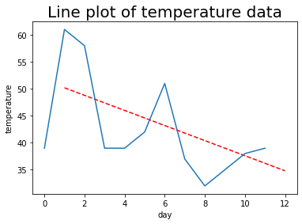

```python
import matplotlib.pyplot as plt


temperatures_df['row'] = range(1, len(temperatures_df) + 1)

x = temperatures_df['row']

#trend
z = np.polyfit(x=x, y=temperatures_df['temperature'], deg=1)
p = np.poly1d(z)
plt.plot(x,p(x),"r--")


# line chart
plt.plot(temperatures_df['temperature']) # plot

# setting a title for the plot, x-axis and y-axis
plt.title('Line plot of temperature data', fontsize=20)
plt.xlabel('day')
plt.ylabel('temperature')

# show the plot
plt.show()
```

### Step 4: Side-by-side boxplots to compare distributions

Central tendency and variability are a combined distribution of your data and allows you to see the big picture of your data. Central tendency are like the hot spots of your data, it shows where most of your data points are located. In a histogram, it would be the bell curve.

The main difference I see between my my data compared to the Zion data is a larger outliers on the Zion data. You can definitely see it in he line graph I printed out after the box graph, they have a larger high and low point from center trend line than my graph. You can also see this in the box graph, the max, min and outlier are farther away from the median line compared to my data.

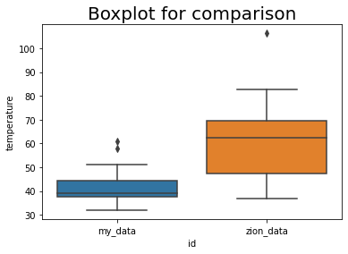

```python
import matplotlib.pyplot as plt
import seaborn as sns
import numpy as np
import random

# creates temperature data for Zion. You don't need to know how this data is created.
# The temperature data created for Zion will be unique to you.
mean = random.randint(temperatures_df['temperature'].min(),temperatures_df['temperature'].max())
std_deviation = random.randint(round(temperatures_df['temperature'].std(),0),round(2*temperatures_df['temperature'].std(),0))
zion_temperatures = np.random.normal(mean, std_deviation, 25)
zion_temperatures = pd.DataFrame(zion_temperatures, columns=['temperature'])

# side-by-side boxplots require the two dataframes to be concatenated and require a variable identifying the data
temperatures_df['id'] = 'my_data'
zion_temperatures['id'] = 'zion_data'
both_temp_df = pd.concat((temperatures_df, zion_temperatures))

# sets a title for the plot, x-axis, and y-axis
plt.title('Boxplot for comparison', fontsize=20)

# prepares the boxplot
sns.boxplot(x="id",y="temperature",data=both_temp_df)


# shows the plot
plt.show()
```

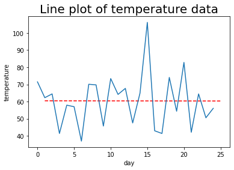

```python
zion_temperatures['row'] = range(1, len(zion_temperatures) + 1)

x = zion_temperatures['row']

#trend
z = np.polyfit(x=x, y=zion_temperatures['temperature'], deg=1)
p = np.poly1d(z)
plt.plot(x,p(x),"r--")

# line chart
plt.plot(zion_temperatures['temperature']) # plot

# setting a title for the plot, x-axis and y-axis
plt.title('Line plot of temperature data', fontsize=20)
plt.xlabel('day')
plt.ylabel('temperature')
# show the plot
plt.show()
```